# DataAnalysisWithPython

```python
import pandas as pd
import numpy as np
```

```python
url = 'https://archive.ics.uci.edu/ml/machine-learning-databases/autos/imports-85.data'
```

```python
df = pd.read_csv(url, header = None)
df.head()
```

|  | 0 | 1 | 2 | 3 | 4 | 5 | 6 | 7 | 8 | 9 | ... | 16 | 17 | 18 | 19 | 20 | 21 | 22 | 23 | 24 | 25 |
| --- | --- | --- | --- | --- | --- | --- | --- | --- | --- | --- | --- | --- | --- | --- | --- | --- | --- | --- | --- | --- | --- |
| 0 | 3 | ? | alfa-romero | gas | std | two | convertible | rwd | front | 88.6 | ... | 130 | mpfi | 3.47 | 2.68 | 9.0 | 111 | 5000 | 21 | 27 | 13495 |
| 1 | 3 | ? | alfa-romero | gas | std | two | convertible | rwd | front | 88.6 | ... | 130 | mpfi | 3.47 | 2.68 | 9.0 | 111 | 5000 | 21 | 27 | 16500 |
| 2 | 1 | ? | alfa-romero | gas | std | two | hatchback | rwd | front | 94.5 | ... | 152 | mpfi | 2.68 | 3.47 | 9.0 | 154 | 5000 | 19 | 26 | 16500 |
| 3 | 2 | 164 | audi | gas | std | four | sedan | fwd | front | 99.8 | ... | 109 | mpfi | 3.19 | 3.40 | 10.0 | 102 | 5500 | 24 | 30 | 13950 |
| 4 | 2 | 164 | audi | gas | std | four | sedan | 4wd | front | 99.4 | ... | 136 | mpfi | 3.19 | 3.40 | 8.0 | 115 | 5500 | 18 | 22 | 17450 |

5 rows × 26 columns

### Data Cleaning and Exploration

###### Assign column Names to replace the intager headers

```python
headers = ['symboling', 'normalized-losses', 'make', 'fuel-type', 'aspiration', 'num-of-doors', 'body-styles', 'drive-wheels',
           'engine-location', 'wheel-base', 'length', 'width', 'height', 'curb-weight', 'engine-type', 'num-of-cylinders',
           'engine-size', 'fuel-system', 'bore', 'stroke', 'compression-ratio', 'horsepower', 'peak-rpm', 'city-mpg',
           'highway-mpg', 'price']
```

```python
print(f'headers\n {headers}')
```

```
headers
 ['symboling', 'normalized-losses', 'make', 'fuel-type', 'aspiration', 'num-of-doors', 'body-styles', 'drive-wheels', 'engine-location', 'wheel-base', 'length', 'width', 'height', 'curb-weight', 'engine-type', 'num-of-cylinders', 'engine-size', 'fuel-system', 'bore', 'stroke', 'compression-ratio', '…
```

```python
df.columns = headers
df.head(10)
```

|  | symboling | normalized-losses | make | fuel-type | aspiration | num-of-doors | body-styles | drive-wheels | engine-location | wheel-base | ... | engine-size | fuel-system | bore | stroke | compression-ratio | horsepower | peak-rpm | city-mpg | highway-mpg | price |
| --- | --- | --- | --- | --- | --- | --- | --- | --- | --- | --- | --- | --- | --- | --- | --- | --- | --- | --- | --- | --- | --- |
| 0 | 3 | ? | alfa-romero | gas | std | two | convertible | rwd | front | 88.6 | ... | 130 | mpfi | 3.47 | 2.68 | 9.0 | 111 | 5000 | 21 | 27 | 13495 |
| 1 | 3 | ? | alfa-romero | gas | std | two | convertible | rwd | front | 88.6 | ... | 130 | mpfi | 3.47 | 2.68 | 9.0 | 111 | 5000 | 21 | 27 | 16500 |
| 2 | 1 | ? | alfa-romero | gas | std | two | hatchback | rwd | front | 94.5 | ... | 152 | mpfi | 2.68 | 3.47 | 9.0 | 154 | 5000 | 19 | 26 | 16500 |
| 3 | 2 | 164 | audi | gas | std | four | sedan | fwd | front | 99.8 | ... | 109 | mpfi | 3.19 | 3.40 | 10.0 | 102 | 5500 | 24 | 30 | 13950 |
| 4 | 2 | 164 | audi | gas | std | four | sedan | 4wd | front | 99.4 | ... | 136 | mpfi | 3.19 | 3.40 | 8.0 | 115 | 5500 | 18 | 22 | 17450 |
| 5 | 2 | ? | audi | gas | std | two | sedan | fwd | front | 99.8 | ... | 136 | mpfi | 3.19 | 3.40 | 8.5 | 110 | 5500 | 19 | 25 | 15250 |
| 6 | 1 | 158 | audi | gas | std | four | sedan | fwd | front | 105.8 | ... | 136 | mpfi | 3.19 | 3.40 | 8.5 | 110 | 5500 | 19 | 25 | 17710 |
| 7 | 1 | ? | audi | gas | std | four | wagon | fwd | front | 105.8 | ... | 136 | mpfi | 3.19 | 3.40 | 8.5 | 110 | 5500 | 19 | 25 | 18920 |
| 8 | 1 | 158 | audi | gas | turbo | four | sedan | fwd | front | 105.8 | ... | 131 | mpfi | 3.13 | 3.40 | 8.3 | 140 | 5500 | 17 | 20 | 23875 |
| 9 | 0 | ? | audi | gas | turbo | two | hatchback | 4wd | front | 99.5 | ... | 131 | mpfi | 3.13 | 3.40 | 7.0 | 160 | 5500 | 16 | 22 | ? |

10 rows × 26 columns

```python
df = df.replace('?', np.nan)
df
```

|  | symboling | normalized-losses | make | fuel-type | aspiration | num-of-doors | body-styles | drive-wheels | engine-location | wheel-base | ... | engine-size | fuel-system | bore | stroke | compression-ratio | horsepower | peak-rpm | city-mpg | highway-mpg | price |
| --- | --- | --- | --- | --- | --- | --- | --- | --- | --- | --- | --- | --- | --- | --- | --- | --- | --- | --- | --- | --- | --- |
| 0 | 3 | NaN | alfa-romero | gas | std | two | convertible | rwd | front | 88.6 | ... | 130 | mpfi | 3.47 | 2.68 | 9.0 | 111 | 5000 | 21 | 27 | 13495 |
| 1 | 3 | NaN | alfa-romero | gas | std | two | convertible | rwd | front | 88.6 | ... | 130 | mpfi | 3.47 | 2.68 | 9.0 | 111 | 5000 | 21 | 27 | 16500 |
| 2 | 1 | NaN | alfa-romero | gas | std | two | hatchback | rwd | front | 94.5 | ... | 152 | mpfi | 2.68 | 3.47 | 9.0 | 154 | 5000 | 19 | 26 | 16500 |
| 3 | 2 | 164 | audi | gas | std | four | sedan | fwd | front | 99.8 | ... | 109 | mpfi | 3.19 | 3.40 | 10.0 | 102 | 5500 | 24 | 30 | 13950 |
| 4 | 2 | 164 | audi | gas | std | four | sedan | 4wd | front | 99.4 | ... | 136 | mpfi | 3.19 | 3.40 | 8.0 | 115 | 5500 | 18 | 22 | 17450 |
| ... | ... | ... | ... | ... | ... | ... | ... | ... | ... | ... | ... | ... | ... | ... | ... | ... | ... | ... | ... | ... | ... |
| 200 | -1 | 95 | volvo | gas | std | four | sedan | rwd | front | 109.1 | ... | 141 | mpfi | 3.78 | 3.15 | 9.5 | 114 | 5400 | 23 | 28 | 16845 |
| 201 | -1 | 95 | volvo | gas | turbo | four | sedan | rwd | front | 109.1 | ... | 141 | mpfi | 3.78 | 3.15 | 8.7 | 160 | 5300 | 19 | 25 | 19045 |
| 202 | -1 | 95 | volvo | gas | std | four | sedan | rwd | front | 109.1 | ... | 173 | mpfi | 3.58 | 2.87 | 8.8 | 134 | 5500 | 18 | 23 | 21485 |
| 203 | -1 | 95 | volvo | diesel | turbo | four | sedan | rwd | front | 109.1 | ... | 145 | idi | 3.01 | 3.40 | 23.0 | 106 | 4800 | 26 | 27 | 22470 |
| 204 | -1 | 95 | volvo | gas | turbo | four | sedan | rwd | front | 109.1 | ... | 141 | mpfi | 3.78 | 3.15 | 9.5 | 114 | 5400 | 19 | 25 | 22625 |

205 rows × 26 columns

```python
print(df.columns)
```

```
Index(['symboling', 'normalized-losses', 'make', 'fuel-type', 'aspiration',
       'num-of-doors', 'body-styles', 'drive-wheels', 'engine-location',
       'wheel-base', 'length', 'width', 'height', 'curb-weight', 'engine-type',
       'num-of-cylinders', 'engine-size', 'fuel-system', 'bore', 'stroke',
       'compression-ratio', 'horsepower', 'peak-rpm', 'city-mpg',
       'highway-mpg', 'price'],
      dtype='object')
```

```python
# Exporting my data to the working directory

df.to_csv('automobiles.csv', index = False)
```

```python
df.dtypes
```

```
symboling              int64
normalized-losses     object
make                  object
fuel-type             object
aspiration            object
num-of-doors          object
body-styles           object
drive-wheels          object
engine-location       object
wheel-base           float64
length               float64
width                float64
height               float64
curb-weight            int64
engine-type           object
num-of-cylinders      object
engine-size            int64
fuel-system           object
bore                  object
stroke                object
compression-ratio    float64
horsepower            object
peak-rpm              object
city-mpg               int64
highway-mpg            int64
price                 object
dtype: object
```

```python
df.describe()
```

|  | symboling | wheel-base | length | width | height | curb-weight | engine-size | compression-ratio | city-mpg | highway-mpg |
| --- | --- | --- | --- | --- | --- | --- | --- | --- | --- | --- |
| count | 205.000000 | 205.000000 | 205.000000 | 205.000000 | 205.000000 | 205.000000 | 205.000000 | 205.000000 | 205.000000 | 205.000000 |
| mean | 0.834146 | 98.756585 | 174.049268 | 65.907805 | 53.724878 | 2555.565854 | 126.907317 | 10.142537 | 25.219512 | 30.751220 |
| std | 1.245307 | 6.021776 | 12.337289 | 2.145204 | 2.443522 | 520.680204 | 41.642693 | 3.972040 | 6.542142 | 6.886443 |
| min | -2.000000 | 86.600000 | 141.100000 | 60.300000 | 47.800000 | 1488.000000 | 61.000000 | 7.000000 | 13.000000 | 16.000000 |
| 25% | 0.000000 | 94.500000 | 166.300000 | 64.100000 | 52.000000 | 2145.000000 | 97.000000 | 8.600000 | 19.000000 | 25.000000 |
| 50% | 1.000000 | 97.000000 | 173.200000 | 65.500000 | 54.100000 | 2414.000000 | 120.000000 | 9.000000 | 24.000000 | 30.000000 |
| 75% | 2.000000 | 102.400000 | 183.100000 | 66.900000 | 55.500000 | 2935.000000 | 141.000000 | 9.400000 | 30.000000 | 34.000000 |
| max | 3.000000 | 120.900000 | 208.100000 | 72.300000 | 59.800000 | 4066.000000 | 326.000000 | 23.000000 | 49.000000 | 54.000000 |

```python
# To show statistics for specific columns

df2 = df[['length','compression-ratio']].describe()
head = ['Length', 'Compression Ratio']
df2.columns = head
df2
```

|  | Length | Compression Ratio |
| --- | --- | --- |
| count | 205.000000 | 205.000000 |
| mean | 174.049268 | 10.142537 |
| std | 12.337289 | 3.972040 |
| min | 141.100000 | 7.000000 |
| 25% | 166.300000 | 8.600000 |
| 50% | 173.200000 | 9.000000 |
| 75% | 183.100000 | 9.400000 |
| max | 208.100000 | 23.000000 |

```python
df.info()
```

```
<class 'pandas.core.frame.DataFrame'>
RangeIndex: 205 entries, 0 to 204
Data columns (total 26 columns):
 #   Column             Non-Null Count  Dtype
---  ------             --------------  -----
 0   symboling          205 non-null    int64
 1   normalized-losses  164 non-null    object
 2   make               205 non-null    object
 3   fuel-type          205 non-null    object
 4   aspiration         205 non-null    object
 5   num-of-doors       203 non-null    object
 6   body-styles        205 non-null    object
 7   drive-wheels       205 non-null    object
 8   engine-location    205 non-null    object
 9   wheel-base         205 non-null    float64
```

[output cut: 18 more lines]

### Data Wrangling

#### converting raw data into usable format

##### deal with missing data and correct data format

```python
missing_data = df.isnull()
missing_data.head(20)
```

|  | symboling | normalized-losses | make | fuel-type | aspiration | num-of-doors | body-styles | drive-wheels | engine-location | wheel-base | ... | engine-size | fuel-system | bore | stroke | compression-ratio | horsepower | peak-rpm | city-mpg | highway-mpg | price |
| --- | --- | --- | --- | --- | --- | --- | --- | --- | --- | --- | --- | --- | --- | --- | --- | --- | --- | --- | --- | --- | --- |
| 0 | False | True | False | False | False | False | False | False | False | False | ... | False | False | False | False | False | False | False | False | False | False |
| 1 | False | True | False | False | False | False | False | False | False | False | ... | False | False | False | False | False | False | False | False | False | False |
| 2 | False | True | False | False | False | False | False | False | False | False | ... | False | False | False | False | False | False | False | False | False | False |
| 3 | False | False | False | False | False | False | False | False | False | False | ... | False | False | False | False | False | False | False | False | False | False |
| 4 | False | False | False | False | False | False | False | False | False | False | ... | False | False | False | False | False | False | False | False | False | False |
| 5 | False | True | False | False | False | False | False | False | False | False | ... | False | False | False | False | False | False | False | False | False | False |
| 6 | False | False | False | False | False | False | False | False | False | False | ... | False | False | False | False | False | False | False | False | False | False |
| 7 | False | True | False | False | False | False | False | False | False | False | ... | False | False | False | False | False | False | False | False | False | False |
| 8 | False | False | False | False | False | False | False | False | False | False | ... | False | False | False | False | False | False | False | False | False | False |
| 9 | False | True | False | False | False | False | False | False | False | False | ... | False | False | False | False | False | False | False | False | False | True |
| 10 | False | False | False | False | False | False | False | False | False | False | ... | False | False | False | False | False | False | False | False | False | False |
| 11 | False | False | False | False | False | False | False | False | False | False | ... | False | False | False | False | False | False | False | False | False | False |
| 12 | False | False | False | False | False | False | False | False | False | False | ... | False | False | False | False | False | False | False | False | False | False |
| 13 | False | False | False | False | False | False | False | False | False | False | ... | False | False | False | False | False | False | False | False | False | False |
| 14 | False | True | False | False | False | False | False | False | False | False | ... | False | False | False | False | False | False | False | False | False | False |
| 15 | False | True | False | False | False | False | False | False | False | False | ... | False | False | False | False | False | False | False | False | False | False |
| 16 | False | True | False | False | False | False | False | False | False | False | ... | False | False | False | False | False | False | False | False | False | False |
| 17 | False | True | False | False | False | False | False | False | False | False | ... | False | False | False | False | False | False | False | False | False | False |
| 18 | False | False | False | False | False | False | False | False | False | False | ... | False | False | False | False | False | False | False | False | False | False |
| 19 | False | False | False | False | False | False | False | False | False | False | ... | False | False | False | False | False | False | False | False | False | False |

20 rows × 26 columns

###### Count Missing Value in Each Column using the for loop

```python
for column in missing_data.columns.values.tolist():
    print(column)
    print(missing_data[column].value_counts())
    print('')
```

```
symboling
False    205
Name: symboling, dtype: int64

normalized-losses
False    164
True      41
Name: normalized-losses, dtype: int64

make
False    205
Name: make, dtype: int64

fuel-type
False    205
Name: fuel-type, dtype: int64

aspiration
False    205
Name: aspiration, dtype: int64

num-of-doors
False    203
True       2
Name: num-of-doors, dtype: int64

body-styles
False    205
Name: body-styles, dtype: int64

drive-wheels
False    205
Name: drive-wheels, dtype: int64

engine-location
False    205
Name: engine-location, dtype: int64

wheel-base
False    205
```

[output cut: 55 more lines]

```
True       2
Name: peak-rpm, dtype: int64

city-mpg
False    205
Name: city-mpg, dtype: int64

highway-mpg
False    205
Name: highway-mpg, dtype: int64

price
False    201
True       4
Name: price, dtype: int64
```

###### Replace the missing values of the "normalized losses" by the mean value

```python
average_norm_loss = df['normalized-losses'].astype(float).mean()
df['normalized-losses'].replace(np.nan, average_norm_loss,inplace = True)
```

##### Replace the NaN in the bore column with the average of the column

```python
avg_bore = df['bore'].astype(float).mean()
df['bore'].replace(np.nan, avg_bore, inplace = True)
```

###### Replacing the ''stroke'' column NaN values with the mean

```python
avg_stroke = df['stroke'].astype(float).mean()
df['stroke'].replace(np.nan, avg_stroke, inplace = True)
```

###### Replacing the NaN values of the 'horsepower' column with the mean

```python
avg_horse = df['horsepower'].astype(float).mean()
df['horsepower'].replace(np.nan, avg_horse, inplace = True)
```

###### Replacing the NaN values of the 'peak-rpm' column with the mean

```python
avg_peak = df['peak-rpm'].astype(float).mean()
df['peak-rpm'].replace(np.nan, avg_peak, inplace = True)
```

###### Replacing the NaN values of the 'num-of-doors' column with the most frequent value

```python
df['num-of-doors'].value_counts().idxmax()
```

```
'four'
```

The four doors appears th most thus we use it for replacement

```python
df['num-of-doors'].replace(np.nan, 'four', inplace = True)
```

Finally dropping the rows without price data since it is the value being predicted

```python
df.dropna(subset = ['price'], axis = 0, inplace = True)
```

```python
# Reset the index since we have dropped rows

df.reset_index(drop = True, inplace = True)
```

```python
df.head()
```

|  | symboling | normalized-losses | make | fuel-type | aspiration | num-of-doors | body-styles | drive-wheels | engine-location | wheel-base | ... | engine-size | fuel-system | bore | stroke | compression-ratio | horsepower | peak-rpm | city-mpg | highway-mpg | price |
| --- | --- | --- | --- | --- | --- | --- | --- | --- | --- | --- | --- | --- | --- | --- | --- | --- | --- | --- | --- | --- | --- |
| 0 | 3 | 122 | alfa-romero | gas | std | two | convertible | rwd | front | 88.6 | ... | 130 | mpfi | 3.47 | 2.68 | 9.0 | 111 | 5000 | 21 | 27 | 13495 |
| 1 | 3 | 122 | alfa-romero | gas | std | two | convertible | rwd | front | 88.6 | ... | 130 | mpfi | 3.47 | 2.68 | 9.0 | 111 | 5000 | 21 | 27 | 16500 |
| 2 | 1 | 122 | alfa-romero | gas | std | two | hatchback | rwd | front | 94.5 | ... | 152 | mpfi | 2.68 | 3.47 | 9.0 | 154 | 5000 | 19 | 26 | 16500 |
| 3 | 2 | 164 | audi | gas | std | four | sedan | fwd | front | 99.8 | ... | 109 | mpfi | 3.19 | 3.40 | 10.0 | 102 | 5500 | 24 | 30 | 13950 |
| 4 | 2 | 164 | audi | gas | std | four | sedan | 4wd | front | 99.4 | ... | 136 | mpfi | 3.19 | 3.40 | 8.0 | 115 | 5500 | 18 | 22 | 17450 |

5 rows × 26 columns

###### Loop through the columns to see if there are any more missing values

```python
missing_data = df.isnull()
missing_data
```

|  | symboling | normalized-losses | make | fuel-type | aspiration | num-of-doors | body-styles | drive-wheels | engine-location | wheel-base | ... | engine-size | fuel-system | bore | stroke | compression-ratio | horsepower | peak-rpm | city-mpg | highway-mpg | price |
| --- | --- | --- | --- | --- | --- | --- | --- | --- | --- | --- | --- | --- | --- | --- | --- | --- | --- | --- | --- | --- | --- |
| 0 | False | False | False | False | False | False | False | False | False | False | ... | False | False | False | False | False | False | False | False | False | False |
| 1 | False | False | False | False | False | False | False | False | False | False | ... | False | False | False | False | False | False | False | False | False | False |
| 2 | False | False | False | False | False | False | False | False | False | False | ... | False | False | False | False | False | False | False | False | False | False |
| 3 | False | False | False | False | False | False | False | False | False | False | ... | False | False | False | False | False | False | False | False | False | False |
| 4 | False | False | False | False | False | False | False | False | False | False | ... | False | False | False | False | False | False | False | False | False | False |
| ... | ... | ... | ... | ... | ... | ... | ... | ... | ... | ... | ... | ... | ... | ... | ... | ... | ... | ... | ... | ... | ... |
| 196 | False | False | False | False | False | False | False | False | False | False | ... | False | False | False | False | False | False | False | False | False | False |
| 197 | False | False | False | False | False | False | False | False | False | False | ... | False | False | False | False | False | False | False | False | False | False |
| 198 | False | False | False | False | False | False | False | False | False | False | ... | False | False | False | False | False | False | False | False | False | False |
| 199 | False | False | False | False | False | False | False | False | False | False | ... | False | False | False | False | False | False | False | False | False | False |
| 200 | False | False | False | False | False | False | False | False | False | False | ... | False | False | False | False | False | False | False | False | False | False |

201 rows × 26 columns

```python
# The for loop to display more precisely

for column in missing_data.columns.values.tolist():
    print(column)
    print(missing_data[column].value_counts())
    print('')
```

```
symboling
False    201
Name: symboling, dtype: int64

normalized-losses
False    201
Name: normalized-losses, dtype: int64

make
False    201
Name: make, dtype: int64

fuel-type
False    201
Name: fuel-type, dtype: int64

aspiration
False    201
Name: aspiration, dtype: int64

num-of-doors
False    201
Name: num-of-doors, dtype: int64

body-styles
False    201
Name: body-styles, dtype: int64

drive-wheels
False    201
Name: drive-wheels, dtype: int64

engine-location
False    201
Name: engine-location, dtype: int64

wheel-base
False    201
Name: wheel-base, dtype: int64

```

[output cut: 48 more lines]

```
peak-rpm
False    201
Name: peak-rpm, dtype: int64

city-mpg
False    201
Name: city-mpg, dtype: int64

highway-mpg
False    201
Name: highway-mpg, dtype: int64

price
False    201
Name: price, dtype: int64
```

Done:-)

### Correcting the data format

```python
df[['bore', 'stroke', 'peak-rpm', 'price']] = df[['bore', 'stroke', 'peak-rpm', 'price']].astype(float)
df[['normalized-losses']] = df[['normalized-losses']].astype(int)
```

```python
df.dtypes
```

```
symboling              int64
normalized-losses      int32
make                  object
fuel-type             object
aspiration            object
num-of-doors          object
body-styles           object
drive-wheels          object
engine-location       object
wheel-base           float64
length               float64
width                float64
height               float64
curb-weight            int64
engine-type           object
num-of-cylinders      object
engine-size            int64
fuel-system           object
bore                 float64
stroke               float64
compression-ratio    float64
horsepower            object
peak-rpm             float64
city-mpg               int64
highway-mpg            int64
price                float64
dtype: object
```

Perfect;

### Data Standardization

```python
# Transform mpg to L/100KM (235 divide by mpg)

df['city-L/100KM'] = 235/df['city-mpg']
```

```python
df['highway-L/100KM'] = 235/df['highway-mpg']

# df.rename(columns={'city-mpg': 'city-L/100KM', 'highway-mpg': 'highway-L100KM'}, inplace = True)
```

```python
# Dropping the converted columns (uncomment if not removed)

df.drop('city-mpg', axis = 1, inplace = True)
df.drop('highway-mpg', axis = 1, inplace = True)
```

```python
df.head()
```

|  | symboling | normalized-losses | make | fuel-type | aspiration | num-of-doors | body-styles | drive-wheels | engine-location | wheel-base | ... | engine-size | fuel-system | bore | stroke | compression-ratio | horsepower | peak-rpm | price | city-L/100KM | highway-L/100KM |
| --- | --- | --- | --- | --- | --- | --- | --- | --- | --- | --- | --- | --- | --- | --- | --- | --- | --- | --- | --- | --- | --- |
| 0 | 3 | 122 | alfa-romero | gas | std | two | convertible | rwd | front | 88.6 | ... | 130 | mpfi | 3.47 | 2.68 | 9.0 | 111 | 5000.0 | 13495.0 | 11.190476 | 8.703704 |
| 1 | 3 | 122 | alfa-romero | gas | std | two | convertible | rwd | front | 88.6 | ... | 130 | mpfi | 3.47 | 2.68 | 9.0 | 111 | 5000.0 | 16500.0 | 11.190476 | 8.703704 |
| 2 | 1 | 122 | alfa-romero | gas | std | two | hatchback | rwd | front | 94.5 | ... | 152 | mpfi | 2.68 | 3.47 | 9.0 | 154 | 5000.0 | 16500.0 | 12.368421 | 9.038462 |
| 3 | 2 | 164 | audi | gas | std | four | sedan | fwd | front | 99.8 | ... | 109 | mpfi | 3.19 | 3.40 | 10.0 | 102 | 5500.0 | 13950.0 | 9.791667 | 7.833333 |
| 4 | 2 | 164 | audi | gas | std | four | sedan | 4wd | front | 99.4 | ... | 136 | mpfi | 3.19 | 3.40 | 8.0 | 115 | 5500.0 | 17450.0 | 13.055556 | 10.681818 |

5 rows × 26 columns

### Data Normalization

###### Transforming the data to a similar range

To range basically from 0 to 1 (0 mean and variance 1)

#### Methods

-Simple feature scaling (x/x.max)  
-Min-max ((x-x.min)/(x-x.max))  
-z-score ((X-mean)/var) -------------where x is the value of that column

```python
df['length'] = df['length']/df['length'].max()
df['width'] = df['width']/df['width'].max()
df['height']= df['height']/df['height'].max()
```

### Binning

To transform continuous numerical data into discrete categorical bins for grouped analysis

```python
# Convert 'horsepower' to intager

df['horsepower'] = df['horsepower'].astype(int, copy = True)
```

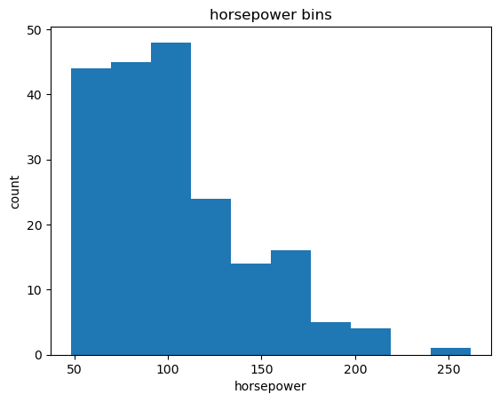

```python
# Plot the histogram for 'horsepower'

%matplotlib inline
import matplotlib.pyplot as plt
plt.hist(df['horsepower'])

plt.xlabel('horsepower')
plt.ylabel('count')
plt.title('horsepower bins')
plt.show()
```

perfetto!

We would like 3 bins grouped as 'low', 'medium', 'high' with equal bandwidth

```python
# First Make the bins

bin = np.linspace(df['horsepower'].min(), df['horsepower'].max(), 4)
bin
```

```
array([ 48.        , 119.33333333, 190.66666667, 262.        ])
```

```python
# Then set the group names

group_names = ['Low', 'Medium', 'High']
```

```python
# Use the pandas' cut to group the tabulated horsepower values

df['horsepower-binned'] = pd.cut(df['horsepower'], bin, labels = group_names, include_lowest = True)
df.head(20)
```

|  | symboling | normalized-losses | make | fuel-type | aspiration | num-of-doors | body-styles | drive-wheels | engine-location | wheel-base | ... | fuel-system | bore | stroke | compression-ratio | horsepower | peak-rpm | price | city-L/100KM | highway-L/100KM | horsepower-binned |
| --- | --- | --- | --- | --- | --- | --- | --- | --- | --- | --- | --- | --- | --- | --- | --- | --- | --- | --- | --- | --- | --- |
| 0 | 3 | 122 | alfa-romero | gas | std | two | convertible | rwd | front | 88.6 | ... | mpfi | 3.47 | 2.68 | 9.0 | 111 | 5000.0 | 13495.0 | 11.190476 | 8.703704 | Low |
| 1 | 3 | 122 | alfa-romero | gas | std | two | convertible | rwd | front | 88.6 | ... | mpfi | 3.47 | 2.68 | 9.0 | 111 | 5000.0 | 16500.0 | 11.190476 | 8.703704 | Low |
| 2 | 1 | 122 | alfa-romero | gas | std | two | hatchback | rwd | front | 94.5 | ... | mpfi | 2.68 | 3.47 | 9.0 | 154 | 5000.0 | 16500.0 | 12.368421 | 9.038462 | Medium |
| 3 | 2 | 164 | audi | gas | std | four | sedan | fwd | front | 99.8 | ... | mpfi | 3.19 | 3.40 | 10.0 | 102 | 5500.0 | 13950.0 | 9.791667 | 7.833333 | Low |
| 4 | 2 | 164 | audi | gas | std | four | sedan | 4wd | front | 99.4 | ... | mpfi | 3.19 | 3.40 | 8.0 | 115 | 5500.0 | 17450.0 | 13.055556 | 10.681818 | Low |
| 5 | 2 | 122 | audi | gas | std | two | sedan | fwd | front | 99.8 | ... | mpfi | 3.19 | 3.40 | 8.5 | 110 | 5500.0 | 15250.0 | 12.368421 | 9.400000 | Low |
| 6 | 1 | 158 | audi | gas | std | four | sedan | fwd | front | 105.8 | ... | mpfi | 3.19 | 3.40 | 8.5 | 110 | 5500.0 | 17710.0 | 12.368421 | 9.400000 | Low |
| 7 | 1 | 122 | audi | gas | std | four | wagon | fwd | front | 105.8 | ... | mpfi | 3.19 | 3.40 | 8.5 | 110 | 5500.0 | 18920.0 | 12.368421 | 9.400000 | Low |
| 8 | 1 | 158 | audi | gas | turbo | four | sedan | fwd | front | 105.8 | ... | mpfi | 3.13 | 3.40 | 8.3 | 140 | 5500.0 | 23875.0 | 13.823529 | 11.750000 | Medium |
| 9 | 2 | 192 | bmw | gas | std | two | sedan | rwd | front | 101.2 | ... | mpfi | 3.50 | 2.80 | 8.8 | 101 | 5800.0 | 16430.0 | 10.217391 | 8.103448 | Low |
| 10 | 0 | 192 | bmw | gas | std | four | sedan | rwd | front | 101.2 | ... | mpfi | 3.50 | 2.80 | 8.8 | 101 | 5800.0 | 16925.0 | 10.217391 | 8.103448 | Low |
| 11 | 0 | 188 | bmw | gas | std | two | sedan | rwd | front | 101.2 | ... | mpfi | 3.31 | 3.19 | 9.0 | 121 | 4250.0 | 20970.0 | 11.190476 | 8.392857 | Medium |
| 12 | 0 | 188 | bmw | gas | std | four | sedan | rwd | front | 101.2 | ... | mpfi | 3.31 | 3.19 | 9.0 | 121 | 4250.0 | 21105.0 | 11.190476 | 8.392857 | Medium |
| 13 | 1 | 122 | bmw | gas | std | four | sedan | rwd | front | 103.5 | ... | mpfi | 3.31 | 3.19 | 9.0 | 121 | 4250.0 | 24565.0 | 11.750000 | 9.400000 | Medium |
| 14 | 0 | 122 | bmw | gas | std | four | sedan | rwd | front | 103.5 | ... | mpfi | 3.62 | 3.39 | 8.0 | 182 | 5400.0 | 30760.0 | 14.687500 | 10.681818 | Medium |
| 15 | 0 | 122 | bmw | gas | std | two | sedan | rwd | front | 103.5 | ... | mpfi | 3.62 | 3.39 | 8.0 | 182 | 5400.0 | 41315.0 | 14.687500 | 10.681818 | Medium |
| 16 | 0 | 122 | bmw | gas | std | four | sedan | rwd | front | 110.0 | ... | mpfi | 3.62 | 3.39 | 8.0 | 182 | 5400.0 | 36880.0 | 15.666667 | 11.750000 | Medium |
| 17 | 2 | 121 | chevrolet | gas | std | two | hatchback | fwd | front | 88.4 | ... | 2bbl | 2.91 | 3.03 | 9.5 | 48 | 5100.0 | 5151.0 | 5.000000 | 4.433962 | Low |
| 18 | 1 | 98 | chevrolet | gas | std | two | hatchback | fwd | front | 94.5 | ... | 2bbl | 3.03 | 3.11 | 9.6 | 70 | 5400.0 | 6295.0 | 6.184211 | 5.465116 | Low |
| 19 | 0 | 81 | chevrolet | gas | std | four | sedan | fwd | front | 94.5 | ... | 2bbl | 3.03 | 3.11 | 9.6 | 70 | 5400.0 | 6575.0 | 6.184211 | 5.465116 | Low |

20 rows × 27 columns

Let's see the number of vehicles in each bin

```python
count_per_group = df['horsepower-binned'].value_counts()
count_per_group
```

```
Low       153
Medium     43
High        5
Name: horsepower-binned, dtype: int64
```

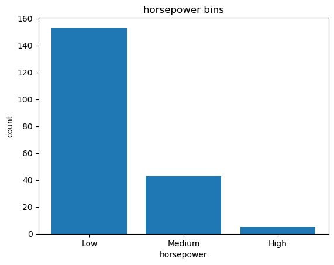

```python
# Ploting the distribution of each bin using a bar graph

plt.bar(group_names, count_per_group)

plt.xlabel('horsepower')
plt.ylabel('count')
plt.title('horsepower bins')
plt.show()
```

### Bins Visualization

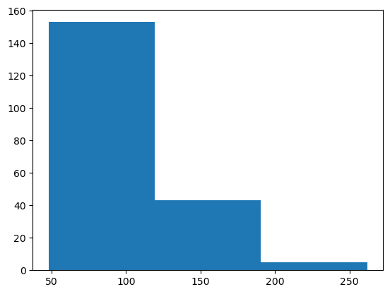

```python
# Histogram plot

plt.hist(df['horsepower'], bins = 3)
```

### Dummy or Indicator Variables

###### Are numerical values used to label categorical values

To assist in possible regression analysis for categorical values

```python
# 'fuel-type' has two unique values 'gas' and 'diesel'

dummy_for_fuel = pd.get_dummies(df['fuel-type'])
dummy_for_fuel.rename(columns = {'gas': 'fuel-type-gas', 'diesel': 'fuel-type-diesel'}, inplace = True)
dummy_for_fuel.head()
```

|  | fuel-type-diesel | fuel-type-gas |
| --- | --- | --- |
| 0 | 0 | 1 |
| 1 | 0 | 1 |
| 2 | 0 | 1 |
| 3 | 0 | 1 |
| 4 | 0 | 1 |

```python
# Append the data as a new column

df = pd.concat([df, dummy_for_fuel], axis = 1)

# Drop original column 'fuel-type'

df.drop('fuel-type', axis = 1, inplace = True)
df.head()
```

|  | symboling | normalized-losses | make | aspiration | num-of-doors | body-styles | drive-wheels | engine-location | wheel-base | length | ... | stroke | compression-ratio | horsepower | peak-rpm | price | city-L/100KM | highway-L/100KM | horsepower-binned | fuel-type-diesel | fuel-type-gas |
| --- | --- | --- | --- | --- | --- | --- | --- | --- | --- | --- | --- | --- | --- | --- | --- | --- | --- | --- | --- | --- | --- |
| 0 | 3 | 122 | alfa-romero | std | two | convertible | rwd | front | 88.6 | 0.811148 | ... | 2.68 | 9.0 | 111 | 5000.0 | 13495.0 | 11.190476 | 8.703704 | Low | 0 | 1 |
| 1 | 3 | 122 | alfa-romero | std | two | convertible | rwd | front | 88.6 | 0.811148 | ... | 2.68 | 9.0 | 111 | 5000.0 | 16500.0 | 11.190476 | 8.703704 | Low | 0 | 1 |
| 2 | 1 | 122 | alfa-romero | std | two | hatchback | rwd | front | 94.5 | 0.822681 | ... | 3.47 | 9.0 | 154 | 5000.0 | 16500.0 | 12.368421 | 9.038462 | Medium | 0 | 1 |
| 3 | 2 | 164 | audi | std | four | sedan | fwd | front | 99.8 | 0.848630 | ... | 3.40 | 10.0 | 102 | 5500.0 | 13950.0 | 9.791667 | 7.833333 | Low | 0 | 1 |
| 4 | 2 | 164 | audi | std | four | sedan | 4wd | front | 99.4 | 0.848630 | ... | 3.40 | 8.0 | 115 | 5500.0 | 17450.0 | 13.055556 | 10.681818 | Low | 0 | 1 |

5 rows × 28 columns

```python
dummy_for_aspiration = pd.get_dummies(df['aspiration'])
dummy_for_aspiration

dummy_for_aspiration.rename(columns = {'std': 'std-aspiration', 'turbo': 'turbo-aspiration'}, inplace = True)

df = pd.concat([df, dummy_for_aspiration], axis = 1)
df.head()

df.drop('aspiration', axis = 1, inplace = True)
```

```python
df.head()
```

|  | symboling | normalized-losses | make | num-of-doors | body-styles | drive-wheels | engine-location | wheel-base | length | width | ... | horsepower | peak-rpm | price | city-L/100KM | highway-L/100KM | horsepower-binned | fuel-type-diesel | fuel-type-gas | std-aspiration | turbo-aspiration |
| --- | --- | --- | --- | --- | --- | --- | --- | --- | --- | --- | --- | --- | --- | --- | --- | --- | --- | --- | --- | --- | --- |
| 0 | 3 | 122 | alfa-romero | two | convertible | rwd | front | 88.6 | 0.811148 | 0.890278 | ... | 111 | 5000.0 | 13495.0 | 11.190476 | 8.703704 | Low | 0 | 1 | 1 | 0 |
| 1 | 3 | 122 | alfa-romero | two | convertible | rwd | front | 88.6 | 0.811148 | 0.890278 | ... | 111 | 5000.0 | 16500.0 | 11.190476 | 8.703704 | Low | 0 | 1 | 1 | 0 |
| 2 | 1 | 122 | alfa-romero | two | hatchback | rwd | front | 94.5 | 0.822681 | 0.909722 | ... | 154 | 5000.0 | 16500.0 | 12.368421 | 9.038462 | Medium | 0 | 1 | 1 | 0 |
| 3 | 2 | 164 | audi | four | sedan | fwd | front | 99.8 | 0.848630 | 0.919444 | ... | 102 | 5500.0 | 13950.0 | 9.791667 | 7.833333 | Low | 0 | 1 | 1 | 0 |
| 4 | 2 | 164 | audi | four | sedan | 4wd | front | 99.4 | 0.848630 | 0.922222 | ... | 115 | 5500.0 | 17450.0 | 13.055556 | 10.681818 | Low | 0 | 1 | 1 | 0 |

5 rows × 29 columns

```python
df.to_csv('cleas-automobile.csv')
```